# Exp8_MLM report

Mrudula & Carina

14 June,2021

**This report highlights the results from the Multi level analysis for Experiment 8.** Data from experiment 8 has already been prepared with the relevant factors such as :

1. Distance: How far ago was the last occurence
2. Distance_type: Was the last occurence a SingleD or a MultipleD trial. If it is MultipleD then Distance_type is 1 and if it is SingleD then it is 2
3. ResponseRel: Whether the previous response was repeated or changed.
4. Validity and Saliency factors were converted to numeric: Valid trials are 1, and invalid and -1 similarly Salient is 1 and nonsalient is -1
5. Only the RTs of SingleD trials were used for analysis

The prepared dataset is saved as *Exp8_DataforMLM.csv* and is loaded to perform the MLM.

### Data Preparation and cleaning

This data is further edited to be prepared for analysis in the following ways

1. Create numeric factor for Previous Response : RR (1) and RC(2)
2. Removing compound trials and choosing only SingleD trials that were used for analysis
3. Centering predictors : within participants as level 1 predictors are participants. This is done using the formula $cwp = Actual value - mean$
   - Previous Response_cwp
   - Distance_cwp
   - Distance_Type_cwp

These are then merged with the main dataframe

# Multi Level Analysis

## 1. Model 1 - similar to ANOVA data

This model replicates the ANOVa on the aggregated data used in the standard analysis. The factors used are:

- Validity: valid (1) and invalid(-1)
- Saliency: Salient(1) and nonsalient(-1)
- Val*Sal interaction: indicating overshadowing if validity effect is larger for salient vs nonsalient trials

### 1. with RTs as dependant variable

```r
randomSlopes_m1<-lmer(RT_io~1+val*sal + (1+val*sal|participant),
                      data=raw.data,
                      REML=F,
                      na.action = "na.omit")


tab_model(randomSlopes_m1, show.se = TRUE,show.stat = TRUE, show.ci = FALSE,show.aic = TRUE, show.loglik = TRUE,
                  dv.labels = "Reaction Time")
```

|  | Reaction Time |  |  |  |
| --- | --- | --- | --- | --- |
| Predictors | Estimates | std. Error | Statistic | p |
| (Intercept) | 565.34 | 8.93 | 63.30 | **<0.001** |
| val | -0.74 | 2.26 | -0.33 | 0.744 |
| sal | -2.85 | 1.78 | -1.60 | 0.109 |
| val * sal | -4.12 | 2.22 | -1.86 | 0.063 |
| Random Effects |  |  |  |  |
| σ<sup>2</sup> | 13318.57 |  |  |  |
| τ<sub>00</sub> <sub>participant</sub> | 5136.96 |  |  |  |
| τ<sub>11</sub> <sub>participant.val</sub> | 134.65 |  |  |  |
| τ<sub>11</sub> <sub>participant.sal</sub> | 3.92 |  |  |  |
| τ<sub>11</sub> <sub>participant.val:sal</sub> | 122.52 |  |  |  |
| ρ<sub>01</sub> | 0.46 |  |  |  |
|  | -0.57 |  |  |  |
|  | 0.23 |  |  |  |
| N <sub>participant</sub> | 67 |  |  |  |
| Observations | 11994 |  |  |  |
| Marginal R<sup>2</sup> / Conditional R<sup>2</sup> | 0.003 / NA |  |  |  |
| AIC | 148347.303 |  |  |  |
| log-Likelihood | -74158.651 |  |  |  |

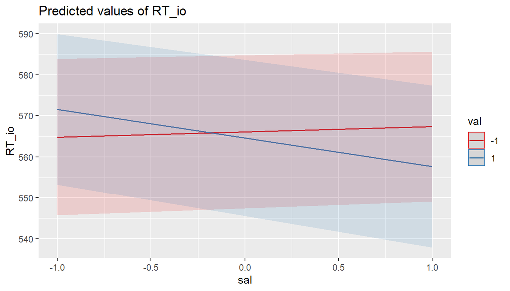

```r
plot_model(randomSlopes_m1, type = "pred", terms = c("sal", "val[minmax]"))
```

```r
summary(randomSlopes_m1)
```

```
## Linear mixed model fit by maximum likelihood . t-tests use Satterthwaite's
##   method [lmerModLmerTest]
## Formula: RT_io ~ 1 + val * sal + (1 + val * sal | participant)
##    Data: raw.data
##
##      AIC      BIC   logLik deviance df.resid
## 148347.3 148458.2 -74158.7 148317.3    11979
##
## Scaled residuals:
##     Min      1Q  Median      3Q     Max
## -3.9643 -0.6430 -0.1117  0.5162  6.0342
##
## Random effects:
##  Groups      Name        Variance  Std.Dev. Corr
##  participant (Intercept)  5136.961  71.673
##              val           134.654  11.604   0.46
##              sal             3.916   1.979  -0.57  0.47
##              val:sal       122.524  11.069   0.23  0.97  0.67
##  Residual                13318.568 115.406
## Number of obs: 11994, groups:  participant, 67
##
## Fixed effects:
##              Estimate Std. Error        df t value Pr(>|t|)
## (Intercept)  565.3394     8.9315   66.9497  63.297   <2e-16 ***
## val           -0.7384     2.2600   84.4747  -0.327   0.7447
## sal           -2.8463     1.7764 1299.4080  -1.602   0.1093
## val:sal       -4.1211     2.2199   84.1748  -1.856   0.0669 .
## ---
## Signif. codes:  0 '***' 0.001 '**' 0.01 '*' 0.05 '.' 0.1 ' ' 1
##
## Correlation of Fixed Effects:
##         (Intr) val    sal
## val      0.161
## sal     -0.070  0.019
## val:sal  0.133  0.387 -0.573
## convergence code: 0
## boundary (singular) fit: see ?isSingular
```

### 2. with ErrorRates

```r
#Error rates

randomSlopes_m1_err<-glmer(err_trials~1+val*sal + (1+val*sal|participant),
                      data=raw.data,
                      na.action = "na.omit", binomial)


summary(randomSlopes_m1_err)
```

```
## Generalized linear mixed model fit by maximum likelihood (Laplace
##   Approximation) [glmerMod]
##  Family: binomial  ( logit )
## Formula: err_trials ~ 1 + val * sal + (1 + val * sal | participant)
##    Data: raw.data
##
##      AIC      BIC   logLik deviance df.resid
##   5519.5   5624.5  -2745.8   5491.5    13386
##
## Scaled residuals:
##     Min      1Q  Median      3Q     Max
## -1.2208 -0.2600 -0.2059 -0.1636  8.0774
##
## Random effects:
##  Groups      Name        Variance Std.Dev. Corr
##  participant (Intercept) 0.55718  0.7464
##              val         0.05818  0.2412   -0.41
##              sal         0.01639  0.1280   -0.37 -0.66
##              val:sal     0.09810  0.3132   -0.07  0.89 -0.90
## Number of obs: 13400, groups:  participant, 67
##
## Fixed effects:
##             Estimate Std. Error z value Pr(>|z|)
## (Intercept) -3.10112    0.13328 -23.268  < 2e-16 ***
## val          0.01361    0.10007   0.136  0.89180
## sal          0.24910    0.09503   2.621  0.00876 **
## val:sal     -0.32214    0.10109  -3.187  0.00144 **
## ---
## Signif. codes:  0 '***' 0.001 '**' 0.01 '*' 0.05 '.' 0.1 ' ' 1
##
## Correlation of Fixed Effects:
##         (Intr) val    sal
## val     -0.687
## sal     -0.417  0.463
## val:sal  0.337 -0.353 -0.843
## convergence code: 0
## Model failed to converge with max|grad| = 0.0672159 (tol = 0.002, component 1)
```

```r
tab_model(randomSlopes_m1_err, show.se = TRUE,show.stat = TRUE, show.ci = FALSE,show.aic = TRUE, show.loglik = TRUE,
                  dv.labels = "Error Rate")
```

|  | Error Rate |  |  |  |
| --- | --- | --- | --- | --- |
| Predictors | Odds Ratios | std. Error | Statistic | p |
| (Intercept) | 0.04 | 0.01 | -23.27 | **<0.001** |
| val | 1.01 | 0.10 | 0.14 | 0.892 |
| sal | 1.28 | 0.12 | 2.62 | **0.009** |
| val * sal | 0.72 | 0.07 | -3.19 | **0.001** |
| Random Effects |  |  |  |  |
| σ<sup>2</sup> | 3.29 |  |  |  |
| τ<sub>00</sub> <sub>participant</sub> | 0.56 |  |  |  |
| τ<sub>11</sub> <sub>participant.val</sub> | 0.06 |  |  |  |
| τ<sub>11</sub> <sub>participant.sal</sub> | 0.02 |  |  |  |
| τ<sub>11</sub> <sub>participant.val:sal</sub> | 0.10 |  |  |  |
| ρ<sub>01</sub> | -0.41 |  |  |  |
|  | -0.37 |  |  |  |
|  | -0.07 |  |  |  |
| ICC | 0.14 |  |  |  |
| N <sub>participant</sub> | 67 |  |  |  |
| Observations | 13400 |  |  |  |
| Marginal R<sup>2</sup> / Conditional R<sup>2</sup> | 0.010 / 0.152 |  |  |  |
| AIC | 5519.506 |  |  |  |
| log-Likelihood | -2745.753 |  |  |  |

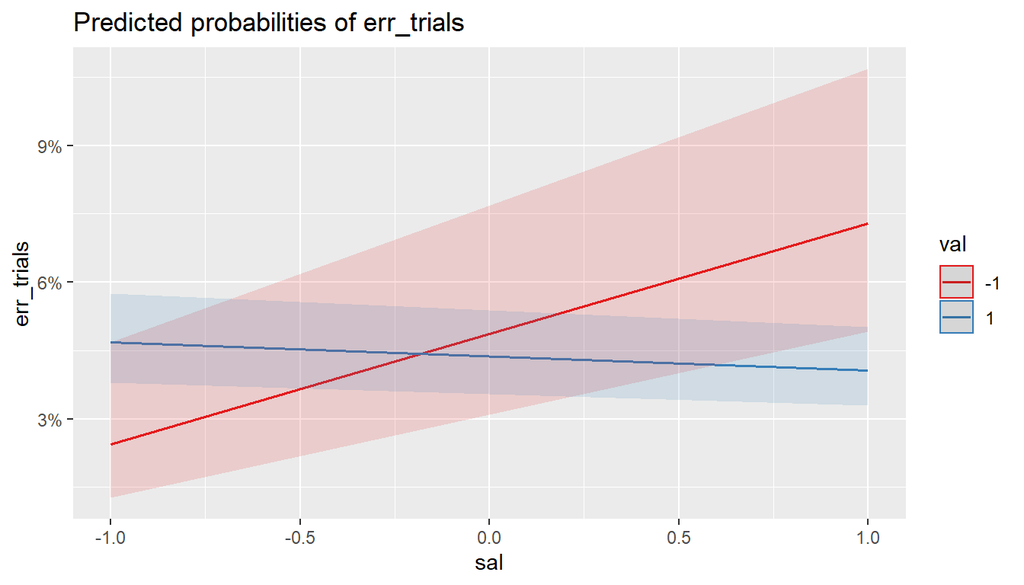

```r
# significant interaction and significant main effect of saliency for both types of randomslopes

plot_model(randomSlopes_m1_err, type = "pred", terms = c("sal", "val[minmax]"))
```

## 2. Model2 : Adding Previous Response and Distance as factors

Will the interaction still survive upon adding these factors? It *almost* does for RT, infact becomes stronger upon adding the binding factors. and strongly does for ER

### 1. with RT

```r
randomSlopes_m2<-lmer(RT_io~1+val*sal + previous_rm_cwp+ Distance_cwp +(1+val*sal + previous_rm_cwp + Distance_cwp|participant),
                      data=raw.data,
                      REML=F,
                      na.action = "na.omit")
tab_model(randomSlopes_m1, randomSlopes_m2, show.se = TRUE,show.stat = TRUE, show.ci = FALSE, show.aic = TRUE, show.loglik = TRUE,
                  dv.labels = "Reaction Time")
```

|  | Reaction Time |  |  |  |  |  |  |  |
| --- | --- | --- | --- | --- | --- | --- | --- | --- |
| Predictors | Estimates | std. Error | Statistic | p | Estimates | std. Error | Statistic | p |
| (Intercept) | 565.34 | 8.93 | 63.30 | **<0.001** | 565.39 | 8.97 | 63.06 | **<0.001** |
| val | -0.74 | 2.26 | -0.33 | 0.744 | -0.78 | 2.29 | -0.34 | 0.732 |
| sal | -2.85 | 1.78 | -1.60 | 0.109 | -2.72 | 1.78 | -1.53 | 0.127 |
| val * sal | -4.12 | 2.22 | -1.86 | 0.063 | -4.24 | 2.23 | -1.90 | 0.057 |
| previous_rm_cwp |  |  |  |  | 7.54 | 3.34 | 2.26 | **0.024** |
| Distance_cwp |  |  |  |  | 0.58 | 0.54 | 1.07 | 0.284 |
| Random Effects |  |  |  |  |  |  |  |  |
| σ<sup>2</sup> | 13318.57 |  |  |  | 13195.11 |  |  |  |
| τ<sub>00</sub> | 5136.96 <sub>participant</sub> |  |  |  | 5179.56 <sub>participant</sub> |  |  |  |
| τ<sub>11</sub> | 134.65 <sub>participant.val</sub> |  |  |  | 143.77 <sub>participant.val</sub> |  |  |  |
|  | 3.92 <sub>participant.sal</sub> |  |  |  | 5.26 <sub>participant.sal</sub> |  |  |  |
|  | 122.52 <sub>participant.val:sal</sub> |  |  |  | 419.27 <sub>participant.previous_rm_cwp</sub> |  |  |  |
|  |  |  |  |  | 2.52 <sub>participant.Distance_cwp</sub> |  |  |  |
|  |  |  |  |  | 125.93 <sub>participant.val:sal</sub> |  |  |  |
| ρ<sub>01</sub> | 0.46 |  |  |  | 0.41 |  |  |  |
|  | -0.57 |  |  |  | -0.44 |  |  |  |
|  | 0.23 |  |  |  | 0.26 |  |  |  |
|  |  |  |  |  | 0.01 |  |  |  |
|  |  |  |  |  | 0.23 |  |  |  |
| N | 67 <sub>participant</sub> |  |  |  | 67 <sub>participant</sub> |  |  |  |
| Observations | 11994 |  |  |  | 11994 |  |  |  |
| Marginal R<sup>2</sup> / Conditional R<sup>2</sup> | 0.003 / NA |  |  |  | 0.005 / NA |  |  |  |
| AIC | 148347.303 |  |  |  | 148321.897 |  |  |  |
| log-Likelihood | -74158.651 |  |  |  | -74132.948 |  |  |  |

```r
summary(randomSlopes_m2)
```

```
## Linear mixed model fit by maximum likelihood . t-tests use Satterthwaite's
##   method [lmerModLmerTest]
## Formula: RT_io ~ 1 + val * sal + previous_rm_cwp + Distance_cwp + (1 +
##     val * sal + previous_rm_cwp + Distance_cwp | participant)
##    Data: raw.data
##
##      AIC      BIC   logLik deviance df.resid
## 148321.9 148528.9 -74132.9 148265.9    11966
##
## Scaled residuals:
##     Min      1Q  Median      3Q     Max
## -3.8754 -0.6425 -0.1132  0.5087  5.9275
##
## Random effects:
##  Groups      Name            Variance  Std.Dev. Corr
##  participant (Intercept)      5179.561  71.969
##              val               143.775  11.991   0.41
##              sal                 5.263   2.294  -0.44  0.43
##              previous_rm_cwp   419.269  20.476   0.26 -0.07  0.15
##              Distance_cwp        2.522   1.588   0.01 -0.13 -0.20 -0.75
##              val:sal           125.925  11.222   0.23  0.92  0.50  0.13 -0.48
##  Residual                    13195.107 114.870
## Number of obs: 11994, groups:  participant, 67
##
## Fixed effects:
##                 Estimate Std. Error       df t value Pr(>|t|)
## (Intercept)     565.3880     8.9661  66.9386  63.059   <2e-16 ***
## val              -0.7840     2.2871  80.1890  -0.343   0.7327
## sal              -2.7166     1.7780 657.4118  -1.528   0.1270
## previous_rm_cwp   7.5417     3.3364  67.1118   2.260   0.0270 *
## Distance_cwp      0.5836     0.5442  97.1428   1.072   0.2862
## val:sal          -4.2392     2.2279  82.3483  -1.903   0.0606 .
## ---
## Signif. codes:  0 '***' 0.001 '**' 0.01 '*' 0.05 '.' 0.1 ' ' 1
##
## Correlation of Fixed Effects:
##             (Intr) val    sal    prvs__ Dstnc_
## val          0.140
## sal         -0.063  0.022
## prvs_rm_cwp  0.189 -0.032  0.027
## Distanc_cwp  0.002 -0.025 -0.014 -0.381
## val:sal      0.137  0.380 -0.574  0.055 -0.102
## convergence code: 0
## boundary (singular) fit: see ?isSingular
```

### 2. With ER

```r
randomSlopes_m2_err<-glmer(err_trials~1+val*sal + previous_rm_cwp+ Distance_cwp + (1+val*sal + previous_rm_cwp + Distance_cwp|participant),
                      data=raw.data,
                      binomial,
                      na.action = "na.omit")
#
# randomSlopes_m2b_err<-glmer(err_trials~1+val*sal + previous_rm_cwp+ Distance_cwp + Distance_type_cwp +(1|participant),
#                       data=raw.data,
#                       binomial,
#                       na.action = "na.omit")
tab_model(randomSlopes_m2_err,randomSlopes_m1_err, show.ci = FALSE, show.p = TRUE, show.stat = TRUE, show.aic = TRUE, show.loglik = TRUE)
```

|  | err_trials |  |  | err_trials |  |  |
| --- | --- | --- | --- | --- | --- | --- |
| Predictors | Odds Ratios | Statistic | p | Odds Ratios | Statistic | p |
| (Intercept) | 0.04 | -21.89 | **<0.001** | 0.04 | -23.27 | **<0.001** |
| val | 1.06 | 0.49 | 0.624 | 1.01 | 0.14 | 0.892 |
| sal | 1.32 | 2.55 | **0.011** | 1.28 | 2.62 | **0.009** |
| previous_rm_cwp | 0.80 | -2.12 | **0.034** |  |  |  |
| Distance_cwp | 1.00 | -0.17 | 0.863 |  |  |  |
| val * sal | 0.70 | -3.06 | **0.002** | 0.72 | -3.19 | **0.001** |
| Random Effects |  |  |  |  |  |  |
| σ<sup>2</sup> | 3.29 |  |  | 3.29 |  |  |
| τ<sub>00</sub> | 0.59 <sub>participant</sub> |  |  | 0.56 <sub>participant</sub> |  |  |
| τ<sub>11</sub> | 0.10 <sub>participant.val</sub> |  |  | 0.06 <sub>participant.val</sub> |  |  |
|  | 0.03 <sub>participant.sal</sub> |  |  | 0.02 <sub>participant.sal</sub> |  |  |
|  | 0.06 <sub>participant.previous_rm_cwp</sub> |  |  | 0.10 <sub>participant.val:sal</sub> |  |  |
|  | 0.00 <sub>participant.Distance_cwp</sub> |  |  |  |  |  |
|  | 0.12 <sub>participant.val:sal</sub> |  |  |  |  |  |
| ρ<sub>01</sub> | -0.43 |  |  | -0.41 |  |  |
|  | -0.39 |  |  | -0.37 |  |  |
|  | 0.46 |  |  | -0.07 |  |  |
|  | 0.37 |  |  |  |  |  |
|  | 0.05 |  |  |  |  |  |
| ICC | 0.16 |  |  | 0.14 |  |  |
| N | 67 <sub>participant</sub> |  |  | 67 <sub>participant</sub> |  |  |
| Observations | 13399 |  |  | 13400 |  |  |
| Marginal R<sup>2</sup> / Conditional R<sup>2</sup> | 0.015 / 0.169 |  |  | 0.010 / 0.152 |  |  |
| AIC | 5527.072 |  |  | 5519.506 |  |  |
| log-Likelihood | -2736.536 |  |  | -2745.753 |  |  |

```r
summary(randomSlopes_m2_err)
```

```
## Generalized linear mixed model fit by maximum likelihood (Laplace
##   Approximation) [glmerMod]
##  Family: binomial  ( logit )
## Formula: err_trials ~ 1 + val * sal + previous_rm_cwp + Distance_cwp +
##     (1 + val * sal + previous_rm_cwp + Distance_cwp | participant)
##    Data: raw.data
##
##      AIC      BIC   logLik deviance df.resid
##   5527.1   5729.7  -2736.5   5473.1    13372
##
## Scaled residuals:
##     Min      1Q  Median      3Q     Max
## -1.3733 -0.2644 -0.2075 -0.1618  8.4314
##
## Random effects:
##  Groups      Name            Variance Std.Dev. Corr
##  participant (Intercept)     0.593493 0.77038
##              val             0.099438 0.31534  -0.43
##              sal             0.034100 0.18466  -0.39 -0.05
##              previous_rm_cwp 0.064402 0.25378   0.46 -0.10  0.57
##              Distance_cwp    0.002015 0.04489   0.37  0.65 -0.56  0.08
##              val:sal         0.120119 0.34658   0.05  0.39 -0.92 -0.71  0.62
## Number of obs: 13399, groups:  participant, 67
##
## Fixed effects:
##                  Estimate Std. Error z value Pr(>|z|)
## (Intercept)     -3.159704   0.144337 -21.891   <2e-16 ***
## val              0.056116   0.114550   0.490   0.6242
## sal              0.279731   0.109591   2.553   0.0107 *
## previous_rm_cwp -0.220246   0.103676  -2.124   0.0336 *
## Distance_cwp    -0.004248   0.024673  -0.172   0.8633
## val:sal         -0.354409   0.115743  -3.062   0.0022 **
## ---
## Signif. codes:  0 '***' 0.001 '**' 0.01 '*' 0.05 '.' 0.1 ' ' 1
##
## Correlation of Fixed Effects:
##             (Intr) val    sal    prvs__ Dstnc_
## val         -0.728
## sal         -0.487  0.541
## prvs_rm_cwp  0.115  0.009  0.065
## Distanc_cwp  0.062  0.067 -0.039 -0.249
## val:sal      0.430 -0.464 -0.880 -0.100  0.060
## convergence code: 0
## Model failed to converge with max|grad| = 0.112887 (tol = 0.002, component 1)
## failure to converge in 10000 evaluations
```

```r
# summary(randomSlopes_m2b_err)
```

## 3. Model3 : Adding the level 2 interaction factors

### with RT

```r
randomSlopes_m3<-lmer(RT_io~1+val*sal*previous_rm_cwp*Distance_cwp+(1+val*sal*previous_rm_cwp*Distance_cwp|participant),
                      data=raw.data,
                      REML=F,
                      na.action = "na.omit")
tab_model(randomSlopes_m3, show.ci = FALSE, show.stat = TRUE, show.aic = TRUE, show.loglik = TRUE)
```

|  | RT_io |  |  |
| --- | --- | --- | --- |
| Predictors | Estimates | Statistic | p |
| (Intercept) | 568.20 | 60.73 | **<0.001** |
| val | -2.47 | -1.01 | 0.314 |
| sal | -1.94 | -0.96 | 0.336 |
| previous_rm_cwp | 8.34 | 1.69 | 0.091 |
| Distance_cwp | 0.86 | 0.91 | 0.362 |
| val * sal | -4.78 | -2.02 | **0.044** |
| val * previous_rm_cwp | -1.89 | -0.43 | 0.666 |
| sal * previous_rm_cwp | 3.94 | 0.95 | 0.344 |
| val * Distance_cwp | 0.26 | 0.27 | 0.787 |
| sal * Distance_cwp | 0.53 | 0.53 | 0.594 |
| previous_rm_cwp * Distance_cwp | 3.33 | 1.62 | 0.105 |
| (val * sal) * previous_rm_cwp | -1.92 | -0.47 | 0.641 |
| (val * sal) * Distance_cwp | -1.02 | -1.01 | 0.313 |
| (val * previous_rm_cwp) * Distance_cwp | -6.08 | -2.91 | **0.004** |
| (sal * previous_rm_cwp) * Distance_cwp | 0.52 | 0.26 | 0.793 |
| (val * sal *previous_rm_cwp)* Distance_cwp | -1.06 | -0.54 | 0.587 |
| Random Effects |  |  |  |
| σ<sup>2</sup> | 12948.69 |  |  |
| τ<sub>00</sub> <sub>participant</sub> | 5615.36 |  |  |
| τ<sub>11</sub> <sub>participant.val</sub> | 153.70 |  |  |
| τ<sub>11</sub> <sub>participant.sal</sub> | 24.91 |  |  |
| τ<sub>11</sub> <sub>participant.previous_rm_cwp</sub> | 631.72 |  |  |
| τ<sub>11</sub> <sub>participant.Distance_cwp</sub> | 3.86 |  |  |
| τ<sub>11</sub> <sub>participant.val:sal</sub> | 128.39 |  |  |
| τ<sub>11</sub> <sub>participant.val:previous_rm_cwp</sub> | 286.04 |  |  |
| τ<sub>11</sub> <sub>participant.sal:previous_rm_cwp</sub> | 147.55 |  |  |
| τ<sub>11</sub> <sub>participant.val:Distance_cwp</sub> | 7.50 |  |  |
| τ<sub>11</sub> <sub>participant.sal:Distance_cwp</sub> | 10.70 |  |  |
| τ<sub>11</sub> <sub>participant.previous_rm_cwp:Distance_cwp</sub> | 54.86 |  |  |
| τ<sub>11</sub> <sub>participant.val:sal:previous_rm_cwp</sub> | 124.87 |  |  |
| τ<sub>11</sub> <sub>participant.val:sal:Distance_cwp</sub> | 12.27 |  |  |
| τ<sub>11</sub> <sub>participant.val:previous_rm_cwp:Distance_cwp</sub> | 65.55 |  |  |
| τ<sub>11</sub> <sub>participant.sal:previous_rm_cwp:Distance_cwp</sub> | 36.67 |  |  |
| τ<sub>11</sub> <sub>participant.val:sal:previous_rm_cwp:Distance_cwp</sub> | 25.71 |  |  |
| ρ<sub>01</sub> | 0.18 |  |  |
|  | 0.11 |  |  |
|  | 0.36 |  |  |
|  | 0.03 |  |  |
|  | 0.08 |  |  |
|  | -0.26 |  |  |
|  | 0.41 |  |  |
|  | 0.09 |  |  |
|  | 0.04 |  |  |
|  | 0.64 |  |  |
|  | -0.19 |  |  |
|  | -0.36 |  |  |
|  | -0.74 |  |  |
|  | 0.49 |  |  |
|  | -0.58 |  |  |
| N <sub>participant</sub> | 67 |  |  |
| Observations | 11994 |  |  |
| Marginal R<sup>2</sup> / Conditional R<sup>2</sup> | 0.006 / NA |  |  |
| AIC | 148472.008 |  |  |
| log-Likelihood | -74083.004 |  |  |

```r
summary(randomSlopes_m3)
```

```
## Linear mixed model fit by maximum likelihood . t-tests use Satterthwaite's
##   method [lmerModLmerTest]
## Formula: RT_io ~ 1 + val * sal * previous_rm_cwp * Distance_cwp + (1 +
##     val * sal * previous_rm_cwp * Distance_cwp | participant)
##    Data: raw.data
##
##      AIC      BIC   logLik deviance df.resid
##   148472   149603   -74083   148166    11841
##
## Scaled residuals:
##     Min      1Q  Median      3Q     Max
## -4.0713 -0.6398 -0.1129  0.5083  5.7633
##
## Random effects:
##  Groups      Name                                 Variance  Std.Dev. Corr
##  participant (Intercept)                           5615.359  74.936
##              val                                    153.699  12.398   0.18
##              sal                                     24.910   4.991   0.11
##              previous_rm_cwp                        631.722  25.134   0.36
##              Distance_cwp                             3.863   1.966   0.03
##              val:sal                                128.394  11.331   0.08
##              val:previous_rm_cwp                    286.045  16.913  -0.26
##              sal:previous_rm_cwp                    147.554  12.147   0.41
##              val:Distance_cwp                         7.499   2.738   0.09
##              sal:Distance_cwp                        10.695   3.270   0.04
##              previous_rm_cwp:Distance_cwp            54.859   7.407   0.64
##              val:sal:previous_rm_cwp                124.871  11.175  -0.19
##              val:sal:Distance_cwp                    12.269   3.503  -0.36
##              val:previous_rm_cwp:Distance_cwp        65.553   8.096  -0.74
##              sal:previous_rm_cwp:Distance_cwp        36.668   6.055   0.49
##              val:sal:previous_rm_cwp:Distance_cwp    25.708   5.070  -0.58
##  Residual                                         12948.693 113.792
##
##
##
##   0.54
##  -0.09  0.36
##  -0.64  0.13  0.25
##   0.44 -0.03 -0.18 -0.86
##  -0.01 -0.58 -0.50 -0.60  0.58
```

[output cut: 54 more lines]

```
## val:sal                               0.04824 *
## val:previous_rm_cwp                   0.66751
## sal:previous_rm_cwp                   0.34531
## val:Distance_cwp                      0.78705
## sal:Distance_cwp                      0.59516
## previous_rm_cwp:Distance_cwp          0.10734
## val:sal:previous_rm_cwp               0.64206
## val:sal:Distance_cwp                  0.31532
## val:previous_rm_cwp:Distance_cwp      0.00449 **
## sal:previous_rm_cwp:Distance_cwp      0.79325
## val:sal:previous_rm_cwp:Distance_cwp  0.58827
## ---
## Signif. codes:  0 '***' 0.001 '**' 0.01 '*' 0.05 '.' 0.1 ' ' 1
## convergence code: 0
## boundary (singular) fit: see ?isSingular
```